# Post-glacial sediment carbon stock — Basin BC

Francisco Rios et al.

2026

# 1 Overview

Full-column post-glacial sediment carbon stock of Basin BC from (i) a geostatistical model of sediment thickness built from parametric echo-sounder profiles and (ii) the geochemistry of the depocentre cores. Sediment thickness is the difference between the basin floor and the basal acoustic horizon (base of the post-glacial sediment fill); each horizon is interpolated by conditional simulation, and the 1000 realisations are propagated through the volume and stock calculations to give Monte Carlo uncertainty (95% simulation intervals throughout, computed as the 2.5th and 97.5th percentiles across the 1000 realisations).

## 1.1 Data and code availability

This notebook accompanies the Data Availability statement of Ríos et al. (manuscript). It reproduces the sediment-thickness simulation, carbon-stock integration, and stratigraphic sensitivity test reported in the manuscript for both basins (Bahía Caribe, BC; Bahía Trampa, BT), switched by the single `basin` YAML parameter above. The raw acoustic picks, core geochemistry, and basin-outline shapefiles are **not** distributed in this repository; they are archived in PANGAEA (Ríos et al., 2020a, b; https://doi.org/10.1594/PANGAEA.900787 for BT and https://doi.org/10.1594/PANGAEA.900786 for BC) or available from the corresponding author on request. To reproduce the analysis, place the following basin-specific input files in the working directory before knitting: `{basin}_surface.csv`, `{basin}_bottom.csv`, `{basin}_core.csv`, `{basin}_area.shp` (with its sidecar files), and the shared `Gravities_BC_BT.csv`.

```r
library(terra)
library(sf)
library(sp)
library(gstat)
library(ggplot2)
library(scales)
library(patchwork)
set.seed(123)
# --- Basin selection -----------------------------------------------------
# Single source of truth: the YAML param. To switch basin, edit the YAML
# header (params: basin: "BC" -> "BT"); nothing in the body needs changing.
basin_label <- params$basin
stopifnot(basin_label %in% c("BC", "BT"))

# Basin-specific acquisition geometry.
# Anisotropy: major-axis azimuth (degrees clockwise from N) and minor/major
# axis ratio. Empirical variogram cutoff and lag width are left to the gstat
# default (1/3 of the bounding-box diagonal; cutoff/15).
# Manuscript: BC ~90 m N-S tracks, BT ~30 m NE-SW tracks.
sep_tracks   <- if (basin_label == "BC") 90 else 30   # nominal track separation (m)
anis_azimuth <- if (basin_label == "BC") 0 else 45
anis_ratio   <- 0.5

# Basin-specific data files
f_surface <- paste0(basin_label, "_surface.csv")
f_bottom  <- paste0(basin_label, "_bottom.csv")
f_core    <- paste0(basin_label, "_core.csv")
f_outline <- paste0(basin_label, "_area.shp")
```

# 2 Data

```r
sup  <- read.csv(f_surface)    # basin floor (x, y, z)
fon  <- read.csv(f_bottom)     # basal acoustic horizon, base of post-glacial sediment fill (x, y, z)
core <- read.csv(f_core)       # composite core: depth, DBD, TC, TOC
shp  <- vect(f_outline)        # basin outline

stopifnot(all(c("x", "y", "z") %in% colnames(sup)))
stopifnot(all(c("x", "y", "z") %in% colnames(fon)))
stopifnot(all(c("depth", "DBD", "TC", "TOC") %in% colnames(core)))
```

```r
# Pair seafloor and basal-horizon picks by nearest neighbour, with a tight
# distance window. This works whether the two files share (x, y) exactly
# (BC: distances ~ 0) or only sample the same survey line at different
# along-track positions (BT). The resulting envelope of fill thickness is
# then used to clip the conditional simulation downstream.

picks_sup <- st_as_sf(sup, coords = c("x", "y"), crs = 32718)
picks_fon <- st_as_sf(fon, coords = c("x", "y"), crs = 32718)
nn        <- st_nearest_feature(picks_fon, picks_sup)
dist_nn   <- as.numeric(st_distance(picks_fon, picks_sup[nn, ], by_element = TRUE))

picks <- data.frame(x       = fon$x,
                    y       = fon$y,
                    z_sup   = sup$z[nn],
                    z_fon   = fon$z,
                    dist_m  = dist_nn)
picks <- picks[picks$dist_m <= 5, ]   # pairing window (m)
picks$thick_picked <- picks$z_sup - picks$z_fon

thick_picked_max <- max(picks$thick_picked, na.rm = TRUE)

if (!is.finite(thick_picked_max) || thick_picked_max <= 0) {
  stop("Picked thickness envelope is not valid. Check sup/fon CSVs and the CRS.")
}

data.frame(n_pairs  = nrow(picks),
           min_m    = round(min(picks$thick_picked,  na.rm = TRUE), 2),
           median_m = round(median(picks$thick_picked, na.rm = TRUE), 2),
           max_m    = round(thick_picked_max, 2))
```

| n_pairs | min_m | median_m | max_m |
| --- | --- | --- | --- |
| 1482 | -0.31 | 10.25 | 16.25 |

```r
sup_sf <- st_as_sf(sup, coords = c("x", "y"), crs = 32718)
fon_sf <- st_as_sf(fon, coords = c("x", "y"), crs = 32718)
sup_sp <- as(sup_sf, "Spatial"); fon_sp <- as(fon_sf, "Spatial")
sup_sp <- sup_sp[!duplicated(coordinates(sup_sp)), ]
fon_sp <- fon_sp[!duplicated(coordinates(fon_sp)), ]
```

# 3 Variogram modelling and cross-validation

```r
# Variogram model: Gaussian without detrending (z ~ 1). The choice was
# validated by sweeping over spherical, exponential and Gaussian models
# with and without first-order detrending for the four surfaces (BC and
# BT, basin floor and basal acoustic horizon); the Gaussian model without
# detrending converged consistently for all four. Empirical variograms use
# the gstat automatic cutoff (1/3 of the bounding-box diagonal) and lag width (cutoff / 15).
# Multi-start fitting (four initial range values scaled to the empirical
# variogram maximum lag) is used to avoid local minima.

vg_sup  <- variogram(z ~ 1, sup_sp)
vg_fon  <- variogram(z ~ 1, fon_sp)
var_sup <- var(sup_sp$z, na.rm = TRUE)
var_fon <- var(fon_sp$z, na.rm = TRUE)

# Multi-start fit. Four initial ranges are scaled to the empirical
# variogram maximum lag; the fit with the lowest SSErr is kept. Negative
# fit components (numerical error) are snapped to zero. A small jitter
# nugget is added if the optimizer converges to nugget = 0; this prevents
# singular kriging matrices when nearby picks lie along the same survey
# track (a known pathology of the Gaussian model with no nugget).
fit_with_restarts <- function(vg, var_z, anis, min_nugget_frac = 0.01) {
  vg_maxdist  <- max(vg$dist)
  init_ranges <- vg_maxdist * c(0.2, 0.4, 0.6, 0.8)
  best_fit <- NULL; best_sse <- Inf
  for (ir in init_ranges) {
    # fit.method = 7: weighted least squares, weights proportional to
    # Npairs / gamma^2 (the gstat/Cressie default weighting scheme).
    f <- tryCatch(
      fit.variogram(vg,
        vgm(psill = 0.7 * var_z, model = "Gau", range = ir,
            nugget = 0.05 * var_z, anis = anis),
        fit.method = 7),
      warning = function(w) NULL, error = function(e) NULL)
    if (is.null(f)) next
    f$psill[f$psill < 0] <- 0
    f$range[f$range < 0] <- 0
    sse <- attr(f, "SSErr")
    if (!is.null(sse) && is.finite(sse) && sse < best_sse) {
      best_sse <- sse; best_fit <- f
    }
  }
  if (is.null(best_fit)) return(NULL)

  # Inject a jitter nugget if the optimizer converged to zero
  psill_struct <- sum(best_fit$psill[best_fit$model != "Nug"])
  has_nug      <- any(best_fit$model == "Nug")
  nug_val      <- if (has_nug) best_fit$psill[best_fit$model == "Nug"] else 0

  if (nug_val < min_nugget_frac * psill_struct) {
    jitter <- min_nugget_frac * psill_struct
    if (has_nug) {
      best_fit$psill[best_fit$model == "Nug"] <- jitter
    } else {
      best_fit <- rbind(
        data.frame(model = "Nug", psill = jitter, range = 0,
                   kappa = 0, ang1 = 0, ang2 = 0, ang3 = 0,
                   anis1 = 1, anis2 = 1),
        best_fit)
      class(best_fit) <- c("variogramModel", "data.frame")
    }
  }
  best_fit
}

fit_sup <- fit_with_restarts(vg_sup, var_sup,
                             anis = c(anis_azimuth, anis_ratio))
fit_fon <- fit_with_restarts(vg_fon, var_fon,
                             anis = c(anis_azimuth, anis_ratio))

stopifnot(!is.null(fit_sup), !is.null(fit_fon))

cv_sup <- krige.cv(z ~ 1, sup_sp, model = fit_sup, nmax = 40, nmin = 5)
cv_fon <- krige.cv(z ~ 1, fon_sp, model = fit_fon, nmax = 40, nmin = 5)

metrics <- function(cv){
  res <- cv$residual
  c(RMSE = sqrt(mean(res^2, na.rm = TRUE)),
    ME   = mean(res, na.rm = TRUE),
    R2   = cor(cv$observed, cv$var1.pred, use = "complete.obs")^2)
}
cv_table <- rbind("basin floor"   = metrics(cv_sup),
                  "basal horizon" = metrics(cv_fon))
knitr::kable(round(cv_table, 3),
             caption = paste0("Basin ", basin_label,
                              ": leave-one-out cross-validation (Supplementary)."))
```

Basin BC: leave-one-out cross-validation (Supplementary).

|  | RMSE | ME | R2 |
| --- | --- | --- | --- |
| basin floor | 1.040 | -0.012 | 0.999 |
| basal horizon | 1.467 | -0.045 | 0.999 |

```r
fit_table <- rbind(
  "basin floor"   = c(nugget = if (any(fit_sup$model == "Nug")) fit_sup$psill[fit_sup$model == "Nug"] else 0,
                      psill  = sum(fit_sup$psill[fit_sup$model != "Nug"]),
                      range  = max(fit_sup$range[fit_sup$model != "Nug"])),
  "basal horizon" = c(nugget = if (any(fit_fon$model == "Nug")) fit_fon$psill[fit_fon$model == "Nug"] else 0,
                      psill  = sum(fit_fon$psill[fit_fon$model != "Nug"]),
                      range  = max(fit_fon$range[fit_fon$model != "Nug"])))
knitr::kable(round(fit_table, 2),
             caption = paste0("Basin ", basin_label,
                              ": fitted Gaussian variogram parameters."))
```

Basin BC: fitted Gaussian variogram parameters.

|  | nugget | psill | range |
| --- | --- | --- | --- |
| basin floor | 14.03 | 1403.06 | 331.26 |
| basal horizon | 29.70 | 2969.61 | 416.32 |

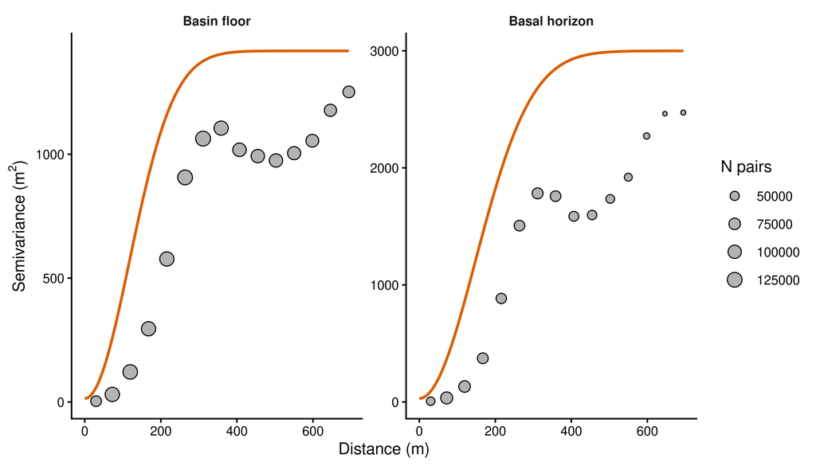

Basin BC: empirical (points) and fitted Gaussian (line) variograms for the basin floor and basal acoustic horizon. Point size scales with the number of pairs per lag.

```r
# Fitted-model lines, evaluated to the maximum observed lag
vline_sup <- variogramLine(fit_sup, maxdist = max(vg_sup$dist))
vline_fon <- variogramLine(fit_fon, maxdist = max(vg_fon$dist))

vg_data <- rbind(
  data.frame(dist = vg_sup$dist, gamma = vg_sup$gamma, np = vg_sup$np,
             horizon = "Basin floor"),
  data.frame(dist = vg_fon$dist, gamma = vg_fon$gamma, np = vg_fon$np,
             horizon = "Basal horizon"))
vline_data <- rbind(
  data.frame(dist = vline_sup$dist, gamma = vline_sup$gamma, horizon = "Basin floor"),
  data.frame(dist = vline_fon$dist, gamma = vline_fon$gamma, horizon = "Basal horizon"))

vg_data$horizon    <- factor(vg_data$horizon,    levels = c("Basin floor", "Basal horizon"))
vline_data$horizon <- factor(vline_data$horizon, levels = c("Basin floor", "Basal horizon"))

p_variogram <- ggplot(vg_data, aes(dist, gamma)) +
  geom_point(aes(size = np), shape = 21, fill = "grey70", colour = "black") +
  geom_line(data = vline_data, colour = "#d95f02", linewidth = 0.8) +
  facet_wrap(~ horizon, scales = "free", ncol = 2) +
  scale_size_continuous(range = c(1, 4), name = "N pairs") +
  labs(x = "Distance (m)",
       y = expression("Semivariance ("*m^2*")")) +
  theme_classic(base_size = 10) +
  theme(legend.position  = "right",
        strip.background = element_blank(),
        strip.text       = element_text(face = "bold"))

p_variogram
```

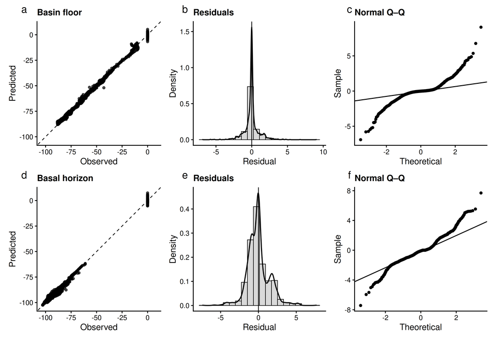

Cross-validation of the basin floor (A–C) and basal horizon (D–F): observed vs predicted, residual distribution, Q–Q (Supplementary).

```r
df_sup <- as.data.frame(cv_sup); df_fon <- as.data.frame(cv_fon)
lims <- range(c(df_sup$observed, df_sup$var1.pred, df_fon$observed, df_fon$var1.pred), na.rm = TRUE)

theme_fig <- theme_classic(base_size = 10) +
  theme(plot.title = element_text(size = 10, face = "bold"), plot.tag.position = c(0.1, 1))

op <- function(df, lab) ggplot(df, aes(observed, var1.pred)) +
  geom_point(size = 1.1, alpha = 0.7) +
  geom_abline(slope = 1, linetype = "dashed", linewidth = 0.4) +
  coord_equal(xlim = lims, ylim = lims) + labs(title = lab, x = "Observed", y = "Predicted") + theme_fig
hh <- function(df) ggplot(df, aes(residual)) +
  geom_histogram(aes(y = after_stat(density)), bins = 20, fill = "grey85", colour = "black", linewidth = 0.3) +
  geom_density(linewidth = 0.6) + geom_vline(xintercept = 0, linewidth = 0.4) +
  labs(title = "Residuals", x = "Residual", y = "Density") + theme_fig
qq <- function(df) ggplot(df, aes(sample = residual)) + stat_qq(size = 1.1) + stat_qq_line(linewidth = 0.5) +
  labs(title = "Normal Q\u2013Q", x = "Theoretical", y = "Sample") + theme_fig

(op(df_sup, "Basin floor") | hh(df_sup) | qq(df_sup)) /
  (op(df_fon, "Basal horizon") | hh(df_fon) | qq(df_fon)) + plot_annotation(tag_levels = "a") -> p_cv

p_cv
```

# 4 Conditional simulation

```r
xrange <- range(c(sup$x, fon$x)); yrange <- range(c(sup$y, fon$y))
resol  <- sep_tracks / 3
grd <- expand.grid(x = seq(xrange[1], xrange[2], by = resol),
                   y = seq(yrange[1], yrange[2], by = resol))
coordinates(grd) <- ~x + y; gridded(grd) <- TRUE
proj4string(grd) <- proj4string(sup_sp)
```

```r
sim_sup <- krige(z ~ 1, sup_sp, grd, model = fit_sup, nsim = 1000, nmax = 50, maxdist = fit_sup$range[2])
sim_fon <- krige(z ~ 1, fon_sp, grd, model = fit_fon, nsim = 1000, nmax = 50, maxdist = fit_fon$range[2])
```

# 5 Sediment thickness and basin volume

```r
r_sup <- mask(crop(rast(sim_sup), shp), shp)
r_fon <- mask(crop(rast(sim_fon), shp), shp)

sim_stack <- r_sup - r_fon
sim_stack <- ifel(sim_stack < 0, 0, sim_stack)

# Clip simulated thickness to the picked envelope. This is the operative
# constraint: it forces each cell, in each realisation, to stay within the
# range of fill thicknesses actually observed in paired picks.
sim_stack <- ifel(sim_stack > thick_picked_max, thick_picked_max, sim_stack)
```

```r
cell_area  <- cellSize(sim_stack)
cover_frac <- rasterize(shp, sim_stack, cover = TRUE)
w          <- cell_area * cover_frac              # effective area per cell (m2)
area_real  <- global(w, "sum", na.rm = TRUE)[1, 1]

vol_r      <- sim_stack * w
vol_values <- as.numeric(global(vol_r, "sum", na.rm = TRUE)[, 1])
mean_vol   <- mean(vol_values)
ci_vol     <- quantile(vol_values, c(0.025, 0.975))   # 95% simulation interval

fmt <- label_scientific()
data.frame(Mean_vol_m3 = fmt(mean_vol),
           SimInt_95_vol = paste0("[", fmt(ci_vol[1]), " - ", fmt(ci_vol[2]), "]"))
```

| Mean_vol_m3 | SimInt_95_vol |
| --- | --- |
| 3.56e+06 | [2.63e+06 - 4.65e+06] |

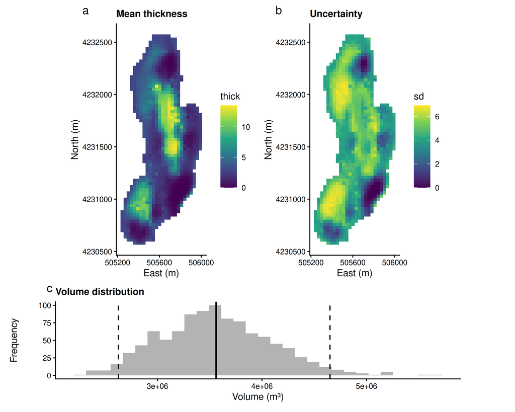

Basin BC: (A) mean simulated sediment thickness, (B) thickness uncertainty (SD), (C) Monte Carlo volume distribution.

```r
r_mean <- app(sim_stack, mean, na.rm = TRUE)
r_sd   <- app(sim_stack, function(x) sd(x, na.rm = TRUE))
df_mean <- as.data.frame(r_mean, xy = TRUE, na.rm = TRUE); colnames(df_mean)[3] <- "thick"
df_sd   <- as.data.frame(r_sd,   xy = TRUE, na.rm = TRUE); colnames(df_sd)[3]   <- "sd"

theme_fig2 <- theme_classic(base_size = 10) +
  theme(plot.title = element_text(size = 10, face = "bold"), plot.tag.position = c(0.08, 1))

pA <- ggplot(df_mean, aes(x, y, fill = thick)) + geom_raster() + scale_fill_viridis_c() +
  coord_equal() + ggtitle("Mean thickness") + labs(x = "East (m)", y = "North (m)") +
  scale_x_continuous(n.breaks = 3) + theme_fig2
pB <- ggplot(df_sd, aes(x, y, fill = sd)) + geom_raster() + scale_fill_viridis_c() +
  coord_equal() + ggtitle("Uncertainty") + labs(x = "East (m)", y = "North (m)") +
  scale_x_continuous(n.breaks = 3) + theme_fig2
pC <- ggplot(data.frame(volume = vol_values), aes(volume)) +
  geom_histogram(bins = 30, fill = "grey70") +
  geom_vline(xintercept = mean_vol, linewidth = 0.8) +
  geom_vline(xintercept = ci_vol, linetype = "dashed", linewidth = 0.6) +
  labs(x = "Volume (m\u00b3)", y = "Frequency", title = "Volume distribution") + theme_fig2

p_thickness <- (pA | pB) / pC + plot_layout(heights = c(3, 1)) + plot_annotation(tag_levels = "a")

p_thickness
```

# 6 Core geochemistry and carbon density profiles

Total carbon (TC) is measured by elemental analysis and organic carbon (TOC) by combustion after acid digestion to remove carbonate; inorganic carbon (TIC) is taken as the difference: TIC = TC − TOC. Dry bulk density (DBD) is converted to kg m<sup>-3</sup> by multiplying by 1000. Organic and inorganic carbon densities are obtained by multiplying DBD by TOC and TIC, each divided by 100 (TOC and TIC are recorded as weight percent). Each density profile is integrated over depth to give cumulative organic and inorganic carbon (kg m<sup>-2</sup>).

```r
core <- core[order(core$depth), ]
core <- core[!duplicated(core$depth), ]

core$rho_kg_m3 <- core$DBD * 1000        # dry bulk density (kg m-3)
core$TIC        <- core$TC - core$TOC      # inorganic carbon (wt%) = TC - OC
core$fC        <- core$TOC / 100          # TOC mass fraction
core$fIC       <- core$TIC / 100          # TIC mass fraction
core$dens_C    <- core$rho_kg_m3 * core$fC    # TOC density (kg C m-3)
core$dens_IC   <- core$rho_kg_m3 * core$fIC   # TIC density (kg C m-3)

dz          <- diff(core$depth) / 100        # m (depth in cm)
core$C_acum  <- cumsum(c(0, core$dens_C[-1]  * dz))
core$IC_acum <- cumsum(c(0, core$dens_IC[-1] * dz))
```

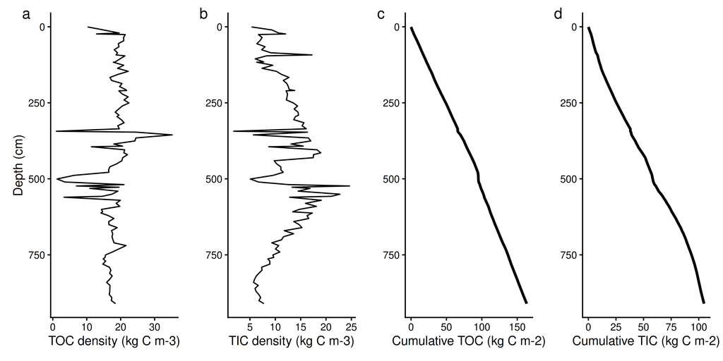

Basin BC: down-core organic and inorganic volumetric carbon density (kg C m-3) and cumulative carbon (kg C m-2).

```r
p1 <- ggplot(core, aes(dens_C,  depth)) + geom_path() + scale_y_reverse() +
  labs(x = "TOC density (kg C m-3)", y = "Depth (cm)") + theme_fig2
p2 <- ggplot(core, aes(dens_IC, depth)) + geom_path() + scale_y_reverse() +
  labs(x = "TIC density (kg C m-3)", y = "") + theme_fig2
p3 <- ggplot(core, aes(C_acum,  depth)) + geom_path(linewidth = 1) + scale_y_reverse() +
  labs(x = "Cumulative TOC (kg C m-2)", y = "") + theme_fig2
p4 <- ggplot(core, aes(IC_acum, depth)) + geom_path(linewidth = 1) + scale_y_reverse() +
  labs(x = "Cumulative TIC (kg C m-2)", y = "") + theme_fig2
p_core <- (p1 | p2 | p3 | p4) + plot_annotation(tag_levels = "a")

p_core
```

# 7 Basin carbon stock (full sediment column)

The carbon held in a column of thickness *H* is the cumulative carbon profile evaluated at *H* (kg C m<sup>-2</sup>). Below the deepest sample, density is held constant at the deepest measured value (this rule is supported by the down-core stabilisation of TOC and TIC densities noted in the manuscript from 7.5 m in BC and 8.0 m in BT; Fig. 3). The per-cell areal carbon density is then multiplied by the same effective cell area used for the volume, and the resulting cell inventories are summed over the basin for each of the 1000 realisations. Evaluated at the core base, the same profile gives the full-column inventory at the depocentre (kg C m<sup>-2</sup>), reported at the end of this section.

```r
H_core_max_cm <- max(core$depth)
acc_C   <- approxfun(core$depth, core$C_acum,  rule = 2)
acc_IC  <- approxfun(core$depth, core$IC_acum, rule = 2)
dens_C_deep  <- tail(core$dens_C,  1)
dens_IC_deep <- tail(core$dens_IC, 1)

# areal carbon density (kg m-2) for thickness H (m), optionally capped at cap_cm,
# extrapolating with constant deepest density below the core base
areal_C <- function(H_m, cap_cm = Inf){
  H_cm  <- pmin(H_m * 100, cap_cm)
  acc_C(pmin(H_cm, H_core_max_cm)) + pmax(H_cm - H_core_max_cm, 0) / 100 * dens_C_deep
}
areal_IC <- function(H_m, cap_cm = Inf){
  H_cm  <- pmin(H_m * 100, cap_cm)
  acc_IC(pmin(H_cm, H_core_max_cm)) + pmax(H_cm - H_core_max_cm, 0) / 100 * dens_IC_deep
}

# sanity check: must reproduce the core inventory at the core base
c(TOC_core_kgm2 = areal_C(H_core_max_cm / 100),
  TIC_core_kgm2 = areal_IC(H_core_max_cm / 100))
```

```
## TOC_core_kgm2 TIC_core_kgm2
##      163.4873      104.8396
```

```r
H_mat <- values(sim_stack)        # cells x 1000 thickness (m)
w_vec <- values(w)[, 1]           # cells effective area (m2)

oc_areal <- apply(H_mat, 2, areal_C)
ic_areal <- apply(H_mat, 2, areal_IC)

stock_C  <- colSums(oc_areal * w_vec, na.rm = TRUE)   # kg per realisation
stock_IC <- colSums(ic_areal * w_vec, na.rm = TRUE)
stock_C_ton  <- stock_C  / 1e3
stock_IC_ton <- stock_IC / 1e3

C_results  <- c(mean = mean(stock_C_ton),
                low95 = quantile(stock_C_ton, 0.025), high95 = quantile(stock_C_ton, 0.975))
IC_results <- c(mean = mean(stock_IC_ton),
                low95 = quantile(stock_IC_ton, 0.025), high95 = quantile(stock_IC_ton, 0.975))
names(C_results) <- names(IC_results) <- c("mean", "low95", "high95")

OC_areal_basin <- mean(stock_C)  / area_real
IC_areal_basin <- mean(stock_IC) / area_real

data.frame(
  TOC_stock_ton = fmt(C_results["mean"]),
  TOC_SimInt_95 = paste0("[", fmt(C_results["low95"]), " - ", fmt(C_results["high95"]), "]"),
  TIC_stock_ton = fmt(IC_results["mean"]),
  TIC_SimInt_95 = paste0("[", fmt(IC_results["low95"]), " - ", fmt(IC_results["high95"]), "]"),
  row.names = NULL
)
```

| TOC_stock_ton | TOC_SimInt_95 | TIC_stock_ton | TIC_SimInt_95 |
| --- | --- | --- | --- |
| 6.51e+04 | [4.82e+04 - 8.49e+04] | 3.8e+04 | [2.83e+04 - 4.87e+04] |

```r
# convergence check: depth-resolved stock vs mean-density x volume (should be ~1)
crosscheck_C_ton <- mean(vol_values) * mean(core$dens_C) / 1e3

# basin-mean fill thickness and bulk (volumetric) carbon density, for
# comparison with the areal densities above (manuscript §3.2: 29.0 kg m-3 in
# BC, 26.5 kg m-3 in BT)
mean_thick    <- mean_vol / area_real                                 # m
vol_c_density <- (OC_areal_basin + IC_areal_basin) / mean_thick       # kg m-3

c(TOC_areal_basin_kgm2 = round(OC_areal_basin, 1),
  TIC_areal_basin_kgm2 = round(IC_areal_basin, 1),
  mean_thick_m         = round(mean_thick, 2),
  vol_c_density_kgm3   = round(vol_c_density, 1),
  convergence_ratio    = round(as.numeric(crosscheck_C_ton / C_results["mean"]), 3))
```

```
## TOC_areal_basin_kgm2 TIC_areal_basin_kgm2         mean_thick_m
##                75.00                43.70                 4.10
##   vol_c_density_kgm3    convergence_ratio
##                28.90                 0.97
```

## 7.1 Extrapolation diagnostics: fraction of the fill below the core base

For columns thicker than the deepest sample, the carbon-density profile is extended with the deepest measured value. The diagnostic below reports, across the 1000 thickness realisations, (i) the fraction of basin area for which the extrapolation is active, (ii) the fraction of sediment volume that sits below the core base (the quantity that actually affects the stock — only this part of the column is filled with the constant deepest density), (iii) the basin thickness maximum, and (iv) the maximum excess over the core base. The map shows the per-cell probability of being thicker than the core base across the 1000 realisations.

```r
H_core_max_m <- H_core_max_cm / 100      # core base in metres

# cells inside the basin (positive effective area, finite thickness in H_mat)
inside <- is.finite(w_vec) & w_vec > 0
H_in   <- H_mat[inside, , drop = FALSE]
a_in   <- w_vec[inside]
A_in   <- sum(a_in)

# --- Per-realisation quantities (vary across the 1000 SGS realisations) --
extrap_per_real <- vapply(seq_len(ncol(H_in)), function(i){
  th <- H_in[, i]; th[is.na(th)] <- 0
  c(area_frac  = sum(a_in[th > H_core_max_m]) / A_in,
    vol_frac   = sum(pmax(th - H_core_max_m, 0) * a_in) / sum(th * a_in),
    max_thick  = max(th),
    max_excess = max(th - H_core_max_m))
}, numeric(4))
extrap_per_real <- as.data.frame(t(extrap_per_real))

# --- Per-cell statistics across the 1000 realisations -------------------
cell_mean <- rowMeans(H_in, na.rm = TRUE)
cell_p95  <- apply(H_in, 1, quantile, probs = 0.95, na.rm = TRUE)

# --- Table 1: extrapolation fractions (95% simulation interval across the
#             1000 realisations) ------------------------------------------
extrap_fractions <- data.frame(
  Metric = c("Area extrapolated (%)",
             "Volume extrapolated (%)"),
  Mean      = c(mean(extrap_per_real$area_frac) * 100,
                mean(extrap_per_real$vol_frac)  * 100),
  SimInt_lo = c(quantile(extrap_per_real$area_frac, 0.025) * 100,
                quantile(extrap_per_real$vol_frac,  0.025) * 100),
  SimInt_hi = c(quantile(extrap_per_real$area_frac, 0.975) * 100,
                quantile(extrap_per_real$vol_frac,  0.975) * 100))
extrap_fractions[, 2:4] <- round(extrap_fractions[, 2:4], 2)

knitr::kable(extrap_fractions,
  caption = paste0("Basin ", basin_label,
                   ": fraction of the basin (area and sediment volume) lying ",
                   "below the depocentre core base (", round(H_core_max_m, 2),
                   " m). 95% simulation interval across the 1000 SGS realisations."))
```

Basin BC: fraction of the basin (area and sediment volume) lying below the depocentre core base (9.11 m). 95% simulation interval across the 1000 SGS realisations.

| Metric | Mean | SimInt_lo | SimInt_hi |
| --- | --- | --- | --- |
| Area extrapolated (%) | 21.22 | 14.52 | 28.9 |
| Volume extrapolated (%) | 24.05 | 20.36 | 28.1 |

```r
# --- Table 2: thickness statistics ---------------------------------------
# Three statistics are reported because they answer different questions:
#   (a) Max cell-mean thickness     : deepest expected thickness anywhere in
#                                     the basin. Matches the mean-thickness map.
#   (b) Max cell-P95 thickness      : conservative upper bound; the 95th
#                                     percentile of the deepest cell.
#   (c) Per-realisation max (mean)  : average of the per-realisation maxima.
#                                     Heavy-tail-sensitive; reflects sporadic
#                                     extreme cells in individual realisations
#                                     rather than the expected basin maximum.
thickness_stats <- data.frame(
  Statistic = c("Max cell-mean thickness (m)",
                "Max cell-P95 thickness (m)",
                "Per-realisation maximum thickness (m)",
                "Maximum excess over core base (m), per-realisation"),
  Value     = c(round(max(cell_mean), 2),
                round(max(cell_p95),  2),
                round(mean(extrap_per_real$max_thick),  2),
                round(mean(extrap_per_real$max_excess), 2)),
  SimInt_lo = c(NA_real_,
                NA_real_,
                round(quantile(extrap_per_real$max_thick,  0.025), 2),
                round(quantile(extrap_per_real$max_excess, 0.025), 2)),
  SimInt_hi = c(NA_real_,
                NA_real_,
                round(quantile(extrap_per_real$max_thick,  0.975), 2),
                round(quantile(extrap_per_real$max_excess, 0.975), 2)))

knitr::kable(thickness_stats,
  caption = paste0("Basin ", basin_label,
                   ": thickness statistics. The first two are single-value ",
                   "summaries over the ensemble (no interval); the last two ",
                   "are per-realisation quantities with 95% simulation ",
                   "interval across the 1000 SGS realisations. The per-",
                   "realisation maximum is sensitive to heavy tails in the ",
                   "conditional simulation ",
                   "and is shown for diagnosis; the figure of mean simulated ",
                   "thickness corresponds to the max cell-mean."))
```

Basin BC: thickness statistics. The first two are single-value summaries over the ensemble (no interval); the last two are per-realisation quantities with 95% simulation interval across the 1000 SGS realisations. The per-realisation maximum is sensitive to heavy tails in the conditional simulation and is shown for diagnosis; the figure of mean simulated thickness corresponds to the max cell-mean.

| Statistic | Value | SimInt_lo | SimInt_hi |
| --- | --- | --- | --- |
| Max cell-mean thickness (m) | 13.52 | NA | NA |
| Max cell-P95 thickness (m) | 16.25 | NA | NA |
| Per-realisation maximum thickness (m) | 16.25 | 16.25 | 16.25 |
| Maximum excess over core base (m), per-realisation | 7.14 | 7.14 | 7.14 |

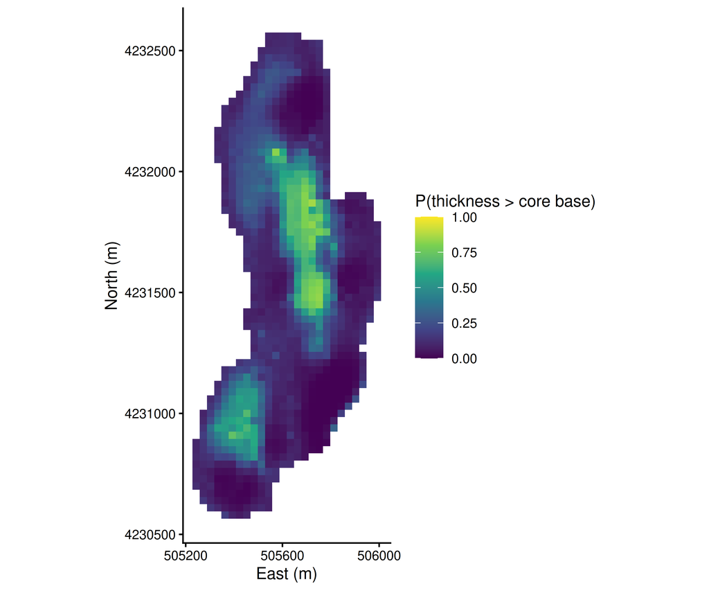

Basin BC: per-cell probability that simulated sediment thickness exceeds the core base across the 1000 realisations.

```r
extrap_prob <- rep(NA_real_, length(w_vec))
extrap_prob[inside] <- rowMeans(H_in > H_core_max_m, na.rm = TRUE)

r_extrap_prob <- sim_stack[[1]]
values(r_extrap_prob) <- extrap_prob
names(r_extrap_prob)  <- "extrap_prob"

df_ep <- as.data.frame(r_extrap_prob, xy = TRUE, na.rm = TRUE)
p_extrap_prob <- ggplot(df_ep, aes(x, y, fill = extrap_prob)) +
  geom_raster() +
  scale_fill_viridis_c(limits = c(0, 1),
                       name = "P(thickness > core base)") +
  coord_equal() + labs(x = "East (m)", y = "North (m)") +
  scale_x_continuous(n.breaks = 3) + theme_fig2

p_extrap_prob
```

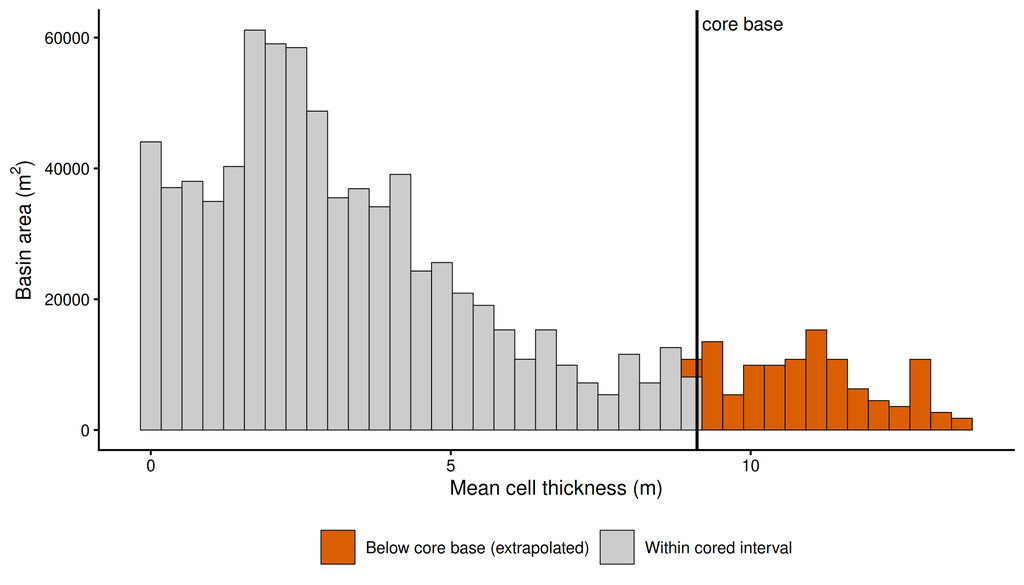

Basin BC: distribution of mean simulated sediment thickness across cells, weighted by effective cell area. Vertical line at the depocentre core base (9.11 m); cells to the right of the line require constant-density extrapolation in the stock calculation.

```r
H_mean_cell <- rowMeans(H_in, na.rm = TRUE)
df_hist <- data.frame(thickness = H_mean_cell,
                      weight    = a_in,
                      side      = ifelse(H_mean_cell > H_core_max_m,
                                         "Below core base (extrapolated)",
                                         "Within cored interval"))

p_thick_hist <- ggplot(df_hist, aes(x = thickness, weight = weight, fill = side)) +
  geom_histogram(bins = 40, colour = "black", linewidth = 0.2) +
  geom_vline(xintercept = H_core_max_m, linewidth = 0.7) +
  annotate("text", x = H_core_max_m, y = Inf, label = " core base",
           hjust = 0, vjust = 1.5, size = 3.2) +
  scale_fill_manual(values = c("Within cored interval"             = "grey80",
                               "Below core base (extrapolated)"    = "#d95f02"),
                    name = NULL) +
  labs(x = "Mean cell thickness (m)",
       y = expression("Basin area ("*m^2*")")) +
  theme_fig2 +
  theme(legend.position = "bottom")


p_thick_hist
```

## 7.2 Stratigraphic sensitivity: bracket on the un-cored fill

The depocentre core samples only the upper portion of the simulated acoustic fill. Two end-member scenarios bracket the basin stock without invoking any external value for the un-cored interval: - **A. Constant deepest measured density (default reported).** The deepest cored value is extended downward through the un-cored fill. Geologically justified when the deep cored facies is interpreted as continuing below the core base (Rios et al., 2020). - **B. Cored interval only (lower bound).** The column inventory is capped at the core base; sediment below this depth is assigned zero carbon. This is the stock that the core directly supports.

```r
# --- Scenario A: default (already computed) -------------------------------
# oc_areal, ic_areal carry the upper-bound (constant deepest density) result.
# --- Scenario B: cored-interval cap ---------------------------------------

oc_areal_B <- apply(H_mat, 2, function(h) areal_C (h, cap_cm = H_core_max_cm))
ic_areal_B <- apply(H_mat, 2, function(h) areal_IC(h, cap_cm = H_core_max_cm))

# --- Summarise each scenario ----------------------------------------------
scenario_stocks <- function(oc_a, ic_a){
  s_C  <- colSums(oc_a * w_vec, na.rm = TRUE) / 1e3   # t per realisation
  s_IC <- colSums(ic_a * w_vec, na.rm = TRUE) / 1e3
  list(OC = c(mean   = mean(s_C),
              low95  = unname(quantile(s_C,  0.025)),
              high95 = unname(quantile(s_C,  0.975))),
       IC = c(mean   = mean(s_IC),
              low95  = unname(quantile(s_IC, 0.025)),
              high95 = unname(quantile(s_IC, 0.975))))
}
sA <- scenario_stocks(oc_areal,   ic_areal)
sB <- scenario_stocks(oc_areal_B, ic_areal_B)


# --- Summary table --------------------------------------------------------
ci <- function(x) paste0("[", fmt(x["low95"]), " - ", fmt(x["high95"]), "]")
pct_default <- function(x, ref) sprintf("%+.1f%%", (x["mean"] - ref["mean"]) / ref["mean"] * 100)

sens_table <- data.frame(
  Scenario       = c("A. Constant deepest measured density (default)",
                     "B. Cored interval only (lower bound)"),
  TOC_stock_ton   = c(fmt(sA$OC["mean"]),  fmt(sB$OC["mean"])),
  TOC_SimInt_95   = c(ci(sA$OC),           ci(sB$OC)),
  TOC_vs_default  = c("0%", pct_default(sB$OC, sA$OC)),
  TIC_stock_ton   = c(fmt(sA$IC["mean"]),  fmt(sB$IC["mean"])),
  TIC_SimInt_95   = c(ci(sA$IC),           ci(sB$IC)),
  TIC_vs_default  = c("0%", pct_default(sB$IC, sA$IC)))


knitr::kable(sens_table,
  caption = paste0("Basin ", basin_label,
                   ": stratigraphic bracket on the basin carbon stock. ",
                   "TOC_vs_default and TIC_vs_default give the change ",
                   "relative to the default (Scenario A)."))
```

Basin BC: stratigraphic bracket on the basin carbon stock. TOC_vs_default and TIC_vs_default give the change relative to the default (Scenario A).

| Scenario | TOC_stock_ton | TOC_SimInt_95 | TOC_vs_default | TIC_stock_ton | TIC_SimInt_95 | TIC_vs_default |
| --- | --- | --- | --- | --- | --- | --- |
| A. Constant deepest measured density (default) | 6.51e+04 | [4.82e+04 - 8.49e+04] | 0% | 3.8e+04 | [2.83e+04 - 4.87e+04] | 0% |
| B. Cored interval only (lower bound) | 4.92e+04 | [3.79e+04 - 6.15e+04] | -24.5% | 3.13e+04 | [2.4e+04 - 3.93e+04] | -17.6% |

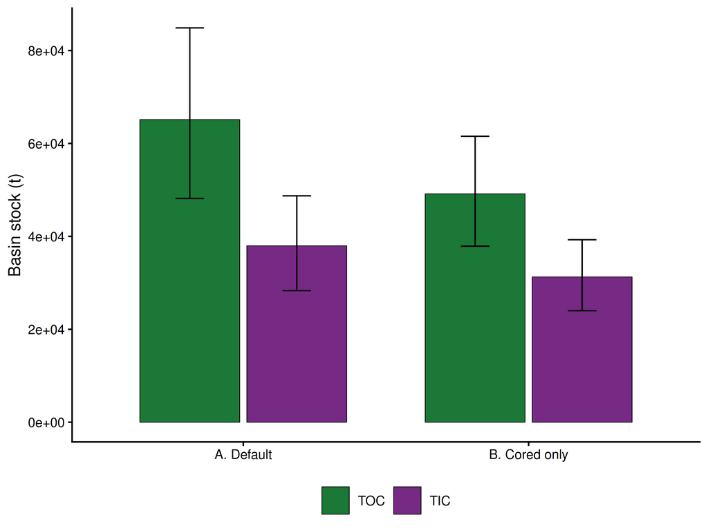

Basin BC: stratigraphic bracket on the basin organic (TOC) and inorganic (TIC) carbon stock. Scenario A extends the deepest measured density to the basal acoustic horizon (default). Scenario B caps the column at the depocentre core base (9.11 m). Bars are means across the 1000 thickness realisations; whiskers are 95% intervals.

```r
# --- Plot -----------------------------------------------------------------
df_sens <- data.frame(
  scenario = factor(rep(c("A. Default", "B. Cored only"), 2),
                    levels = c("A. Default", "B. Cored only")),
  pool     = factor(rep(c("TOC", "TIC"), each = 2),
                    levels = c("TOC", "TIC")),
  mean     = c(sA$OC["mean"],  sB$OC["mean"],
               sA$IC["mean"],  sB$IC["mean"]),
  low95    = c(sA$OC["low95"], sB$OC["low95"],
               sA$IC["low95"], sB$IC["low95"]),
  high95   = c(sA$OC["high95"], sB$OC["high95"],
               sA$IC["high95"], sB$IC["high95"]))

p_sens <- ggplot(df_sens, aes(scenario, mean, fill = pool)) +
  geom_col(position = position_dodge(width = 0.75), width = 0.7,
           colour = "black", linewidth = 0.2) +
  geom_errorbar(aes(ymin = low95, ymax = high95),
                position = position_dodge(width = 0.75), width = 0.2,
                linewidth = 0.4) +
  scale_y_continuous(labels = label_scientific()) +
  scale_fill_manual(values = c("TOC" = "#1b7837", "TIC" = "#762a83")) +
  labs(x = NULL, y = "Basin stock (t)", fill = NULL) +
  theme_fig2 + theme(legend.position = "bottom")


p_sens
```

```r
OC_col_core <- max(core$C_acum)        # depocentre full-column TOC (kg C m-2)
IC_col_core <- max(core$IC_acum)       # depocentre full-column TIC (kg C m-2)
TC_col_core <- OC_col_core + IC_col_core
IC_fraction <- IC_col_core / TC_col_core      # depocentre TIC fraction of TC

# Basin-mean TIC fraction, for comparison with the depocentre value above
# (manuscript Table 1, row "TIC, basin / depocentre (%)")
IC_basin_fraction <- IC_areal_basin / (OC_areal_basin + IC_areal_basin)

# Depocentre concentration factor: depocentre full-column TC inventory
# divided by the basin-mean areal TC density (manuscript §3.2 and Table 1,
# "Depocentre concentration factor (column / basin-mean)"). This is a
# different quantity from the sediment-focusing factor computed in the
# "Volumetric concentration of the sediment fill" section below, which
# compares the high-thickness zone's volume and area fractions.
depocentre_conc_factor <- TC_col_core / (OC_areal_basin + IC_areal_basin)

c(TOC_col_core_kgm2       = round(OC_col_core, 1),
  TIC_col_core_kgm2       = round(IC_col_core, 1),
  TC_col_core_kgm2       = round(TC_col_core, 1),
  TIC_fraction_depocentre = round(IC_fraction, 3),
  TIC_fraction_basin      = round(IC_basin_fraction, 3),
  depocentre_conc_factor = round(depocentre_conc_factor, 2))
```

```
##       TOC_col_core_kgm2       TIC_col_core_kgm2        TC_col_core_kgm2
##                 163.500                 104.800                 268.300
## TIC_fraction_depocentre      TIC_fraction_basin  depocentre_conc_factor
##                   0.391                   0.368                   2.260
```

# 8 Surface inventory (upper 10 cm) from replicate gravity cores

The upper-10 cm inventory at the depocentre is taken from replicate gravity cores, summarised as mean and standard deviation across cores. For each core the carbon density profile is integrated from 0 to 10 cm (density interpolated on a fine grid, the shallowest value extended to the surface). Total carbon is computed directly from TC, so it is returned for every core even where organic carbon is not measured.

```r
grav <- read.csv("Gravities_BC_BT.csv")    # cores, depth, DBD, TC, TOC
grav <- grav[grepl(paste0("^", basin_label), grav$cores), ]   # selects this basin from the shared CSV

acc10 <- function(d, zmax = 10){
  d <- d[order(d$depth), ]
  integ <- function(depth, dens){
    ok <- is.finite(depth) & is.finite(dens)
    depth <- depth[ok]; dens <- dens[ok]
    if (length(depth) == 0) return(NA_real_)
    zg <- seq(0, zmax, by = 0.1)
    g  <- if (length(depth) == 1) rep(dens, length(zg))
          else approx(depth, dens, xout = zg, rule = 2)$y
    zm <- zg / 100
    sum(diff(zm) * (head(g, -1) + tail(g, -1)) / 2)   # trapezoidal integral
  }
  rho <- d$DBD * 1000
  data.frame(TOC_10cm = integ(d$depth, rho * d$TOC / 100),
             TIC_10cm = integ(d$depth, rho * (d$TC - d$TOC) / 100),
             TC_10cm = integ(d$depth, rho * d$TC / 100))   # TC: no OC needed
}

surf_tab <- do.call(rbind, by(grav, grav$cores, acc10))
surf_tab$core <- rownames(surf_tab)
surf_tab <- surf_tab[, c("core", "TOC_10cm", "TIC_10cm", "TC_10cm")]
rownames(surf_tab) <- NULL

knitr::kable(surf_tab, digits = 2,
             caption = "Upper-10 cm carbon inventory per gravity core (kg C m-2)")
```

Upper-10 cm carbon inventory per gravity core (kg C m-2)

| core | TOC_10cm | TIC_10cm | TC_10cm |
| --- | --- | --- | --- |
| BCGr1 | NA | NA | 2.40 |
| BCGr2 | 1.24 | 0.71 | 1.95 |
| BCGr3 | 1.64 | 0.98 | 2.62 |

```r
surf_stats <- function(x){
  x <- x[is.finite(x)]
  c(mean = mean(x), sd = sd(x), cv = sd(x) / mean(x), n = length(x))
}
surf_summary <- rbind(OC    = surf_stats(surf_tab$OC_10cm),
                      IC    = surf_stats(surf_tab$IC_10cm),
                      total = surf_stats(surf_tab$TC_10cm))
knitr::kable(round(surf_summary, 3),
             caption = "Upper-10 cm inventory across cores: mean, SD, CV (kg C m-2). TOC and TIC use cores with measured TOC; total uses all cores.")
```

|  | mean | sd | cv | n |
| --- | --- | --- | --- | --- |
| OC | NA | NA | NA | 0 |
| IC | NA | NA | NA | 0 |
| total | 2.321 | 0.34 | 0.146 | 3 |

```r
surf_mean      <- surf_summary["total", "mean"]
surf_sd        <- surf_summary["total", "sd"]
col_to_surface <- TC_col_core / surf_mean

round(c(n_cores                 = surf_summary["total", "n"],
        column_to_surface_ratio = col_to_surface), 0)
```

```
##                 n_cores column_to_surface_ratio
##                       3                     116
```

# 9 Volumetric concentration of the sediment fill

Because carbon density is held constant across the basin, carbon per cell is proportional to sediment thickness, so the fraction of carbon in any region equals the fraction of sediment **volume** there. The high-thickness zone is defined as the area where mean thickness exceeds 50% of the basin maximum. Its area fraction, volume fraction, and the ratio between them (the sediment-focusing factor) describe how strongly the fill — and, under uniform density, the carbon — is concentrated toward the centre. These are geometric measures, not compositional heterogeneity, which a single core cannot resolve. This sediment-focusing factor is a purely geometric diagnostic of the high-thickness zone and should not be confused with the depocentre concentration factor reported in the Summary section below, which compares the depocentre column inventory with the basin-mean areal carbon density (manuscript §3.2, Table 1).

```r
H  <- values(r_mean)[, 1]      # mean thickness per cell (m)
a  <- values(w)[, 1]           # effective cell area (m2)
ok <- is.finite(H) & is.finite(a) & a > 0
H  <- H[ok]; a <- a[ok]
vol <- H * a                   # sediment volume per cell (proportional to carbon)

thr  <- 0.50 * max(H)          # depocentre threshold: >= 50% of maximum thickness
depo <- H >= thr

depo_area_frac <- sum(a[depo])   / sum(a)
depo_vol_frac  <- sum(vol[depo]) / sum(vol)
focus_factor   <- depo_vol_frac / depo_area_frac   # sediment-focusing factor

conc_tab <- data.frame(
  Metric = c("High-thickness zone area fraction",
             "High-thickness zone volume fraction",
             "Sediment-focusing factor (volume / area)"),
  Value  = round(c(depo_area_frac, depo_vol_frac, focus_factor), 3))
knitr::kable(conc_tab,
  caption = paste0("Basin ", basin_label,
                   ": high-thickness zone (mean thickness >= 50% of basin ",
                   "maximum), geometric concentration of the sediment fill ",
                   "(= carbon, under uniform density). Distinct from the ",
                   "depocentre concentration factor reported in the Summary ",
                   "section (column inventory / basin-mean areal density)."))
```

Basin BC: high-thickness zone (mean thickness >= 50% of basin maximum), geometric concentration of the sediment fill (= carbon, under uniform density). Distinct from the depocentre concentration factor reported in the Summary section (column inventory / basin-mean areal density).

| Metric | Value |
| --- | --- |
| High-thickness zone area fraction | 0.196 |
| High-thickness zone volume fraction | 0.473 |
| Sediment-focusing factor (volume / area) | 2.417 |

```r
r_bath  <- app(r_sup, mean, na.rm = TRUE)              # mean basin-floor surface
df_bath <- as.data.frame(r_bath,  xy = TRUE, na.rm = FALSE); colnames(df_bath)[3]  <- "depth"
df_thick <- as.data.frame(r_mean, xy = TRUE, na.rm = FALSE); colnames(df_thick)[3] <- "thick"

# Survey-track points (use the basin-floor picks as the operative track set)
df_tracks <- data.frame(x = sup$x, y = sup$y)

# --- Depocentre core coordinates -----------------------------------------
# Recorded in degrees-decimal-minutes, WGS84:
#   BC: 52 04.010 S, 74 55.000 W
#   BT: 52 12.840 S, 74 50.540 W
# Reproject to UTM Zone 18S (EPSG:32718) to match the project CRS.
core_coords <- data.frame(
  basin = c("BC", "BT"),
  lat   = c(-(52 +  4.010/60), -(52 + 12.840/60)),
  lon   = c(-(74 + 55.000/60), -(74 + 50.540/60)))
core_xy_all <- as.data.frame(st_coordinates(
  st_transform(
    st_as_sf(core_coords, coords = c("lon", "lat"), crs = 4326),
    crs = 32718)))
core_xy_all$basin <- core_coords$basin
colnames(core_xy_all)[1:2] <- c("x", "y")

# Select the row for the current basin
core_xy <- core_xy_all[core_xy_all$basin == basin_label, c("x", "y")]

p_overview <- ggplot() +
  geom_raster(data = df_bath, aes(x, y, fill = depth)) +
  geom_contour(data = df_thick, aes(x, y, z = thick),
               breaks = thr, colour = "red", linewidth = 0.6) +
  geom_point(data = df_tracks, aes(x, y),
             colour = "white", size = 0.15, alpha = 0.6) +
  geom_point(data = core_xy, aes(x, y),
             shape = 24, fill = "red", colour = "black", size = 3, stroke = 0.6) +
  scale_fill_viridis_c(name = "Basin floor (m)", na.value = "transparent") +
  coord_equal() +
  labs(x = "East (m)", y = "North (m)") +
  scale_x_continuous(n.breaks = 3) +
  theme_fig2


# Print the reprojected coordinates for the manuscript / records
cat("Depocentre core position (UTM Zone 18S, EPSG:32718):\n")
```

```
## Depocentre core position (UTM Zone 18S, EPSG:32718):
```

```r
print(core_xy_all)
```

```
##          x       y basin
## 1 505712.4 4231525    BC
## 2 510772.2 4215148    BT
```

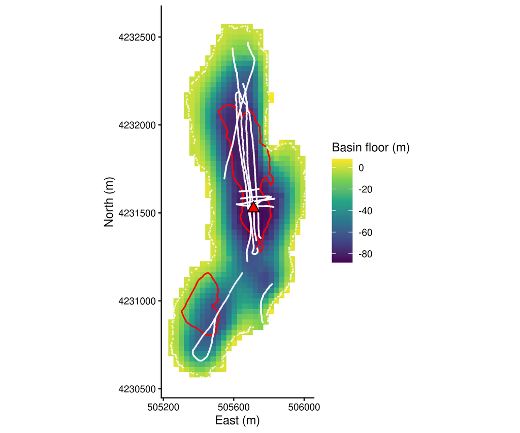

Basin BC: mean basin-floor bathymetry (viridis), survey-track points used in the conditional simulation (white dots), depocentre core position (red triangle), and depocentre boundary defined as mean thickness >= 50% of maximum (red contour). This figure provides the basis for Fig. 1b/1c (bathymetry, survey tracks, core site) and the high-thickness zone shown in Fig. 2c/2d of the manuscript.

```r
p_overview
```

# 10 Summary

| Quantity | Value |
| --- | --- |
| Basin area (m2) | 868,902 |
| Basin volume (m3) | 3.56e+06 |
| Full-column TOC stock (t) | 6.51e+04 |
| Full-column TIC stock (t) | 3.8e+04 |
| Basin-mean TOC areal density (kg C m-2) | 75 |
| Basin-mean TIC areal density (kg C m-2) | 43.7 |
| Basin-mean volumetric carbon density (kg C m-3) | 28.9 |
| Basin-mean TIC fraction | 0.368 |
| Depocentre full-column TOC (kg C m-2) | 163.5 |
| Depocentre full-column TIC (kg C m-2) | 104.8 |
| Depocentre TIC fraction | 0.391 |
| Surficial stock total, gravity cores (kg C m-2) | 2.32 |
| Surficial stock SD, gravity cores (kg C m-2) | 0.34 |
| Column-to-surface ratio | 116 |
| Depocentre concentration factor (column / basin-mean) | 2.26 |
| Sediment-focusing factor (volume / area, high-thickness zone) | 2.42 |